# Laboratorio 2: Algoritmos de aprendizaje de máquinas

- Eric Mendoza 15002
- Marlon Fuentes 15240

## Preparación de entorno de ejecución

### Carga de librerías

```python
import os

import pandas as pd
import numpy as np

import seaborn as sns
color = sns.color_palette()
sns.set_style('darkgrid')

import matplotlib.pyplot as plt
%matplotlib inline

from scipy import stats
import copy

from sklearn.linear_model import LinearRegression
from sklearn.metrics import mean_squared_error
from sklearn.model_selection import train_test_split, cross_val_score

from sklearn import neighbors
from sklearn import preprocessing
from sklearn.model_selection import StratifiedShuffleSplit
from sklearn.preprocessing import StandardScaler
from sklearn.neighbors import KNeighborsClassifier
from sklearn.model_selection import train_test_split
from sklearn.metrics import confusion_matrix
from sklearn.cluster import KMeans
from sklearn.linear_model import RidgeCV
```

### Carga de data

Cargar train.csv desde github.

```python
url = 'https://raw.githubusercontent.com/fuentesmarlon/CLUSTERING-PCA-APRIORI/master/train.csv'
df = pd.read_csv(url)
```

## 1. Preprocesamiento de Data

Kaggle provee dos conjuntos de datos para realizar las pruebas, por lo cual no es necesario realizar la división en dos conjuntos utilizando muestreo aleatorio. Sin embargo, por razones educativas, se procede a realizar la división del dataset *train.csv*.

### Procesamiento de valores nulos

A continuación se muestran todos los valores que son nulos dentro del dataset.

```python
df.isnull().sum().sum()
```

```
6965
```

Se tienen 6965 valores nulos. No se pueden eliminar directamente los valores nulos dentro del dataset debido a que en ciertas columnas significan algo. Sin embargo, en las columnas que no significan nada, serán llenados con la moda o la media (dependiendo del tipo de dato).

```python
# Eliminar nulos de MSZoning
df['MSZoning'] = df['MSZoning'].fillna(df['MSZoning'].mode()[0])
```

```python
# Elimnar nulos de LotFrontage
df['LotFrontage'] = df.groupby('Neighborhood')['LotFrontage'].transform(lambda x: x.fillna(x.median()))
```

```python
# Eliminar nulos de Utilidades
df['Utilities'] = df['Utilities'].fillna(df['Utilities'].mode()[0])
```

```python
# Exterior1st
df['Exterior1st'] = df['Exterior1st'].fillna(df['Exterior1st'].mode()[0])
```

```python
# Exterior2nd
df['Exterior2nd'] = df['Exterior2nd'].fillna(df['Exterior2nd'].mode()[0])
```

```python
df["MasVnrType"] = df["MasVnrType"].fillna(df['MasVnrType'].mode()[0])
```

```python
df["MasVnrArea"] = df["MasVnrArea"].fillna(df['MasVnrArea'].mode()[0])
```

```python
df['Electrical'] = df['Electrical'].fillna(df['Electrical'].mode()[0])
```

```python
df['KitchenQual'] = df['KitchenQual'].fillna(df['KitchenQual'].mode()[0])
```

```python
df['Functional'] = df['Functional'].fillna(df['Functional'].mode()[0])
```

```python
df['Alley'] = df['Alley'].fillna(df['Alley'].mode()[0])
```

```python
df['SaleType'] = df['SaleType'].fillna(df['SaleType'].mode()[0])
```

```python
# En las siguientes columnas NA significa que no existe el valor determinado
for col in ('BsmtQual', 'BsmtCond', 'BsmtExposure', 'BsmtFinType1', 'BsmtFinType2'):
    df[col] = df[col].fillna('None')
```

```python
for col in ('BsmtFinSF1', 'BsmtFinSF2', 'BsmtUnfSF','TotalBsmtSF', 'BsmtFullBath', 'BsmtHalfBath'):
    df[col] = df[col].fillna(0)
```

```python
for col in ('GarageType', 'GarageFinish', 'GarageQual', 'GarageCond'):
    df[col] = df[col].fillna('None')
```

```python
df['FireplaceQu'] = df['FireplaceQu'].fillna('None')
```

```python
for col in ('GarageYrBlt', 'GarageArea', 'GarageCars'):
    df[col] = df[col].fillna(0)
```

```python
df['PoolQC'] = df['PoolQC'].fillna('None')
```

```python
df['Fence'] = df['Fence'].fillna('None')
```

```python
df['MiscFeature'] = df['MiscFeature'].fillna('None')
```

Con lo realizado anteriormente, se reduce el número de nulos a cero. Ahora se procederá a realizar la división del conjunto de datos.

```python
df.isnull().sum().sum()
```

```
0
```

### Corrección de tipos de variables

Ahora se le debe asignar el tipo de variable correcto a cada una de las columnas.

```python
df['Id'] = df['Id']
df['MSSubClass'] = df['MSSubClass'].astype('category')
df['MSZoning'] = df['MSZoning'].astype('category')
df['Street'] = df['Street'].astype('category')
df['Alley'] = df['Alley'].astype('category')
df['LotShape'] = df['LotShape'].astype('category')
df['LandContour'] = df['LandContour'].astype('category')
df['Utilities'] = df['Utilities'].astype('category')
df['LotConfig'] = df['LotConfig'].astype('category')
df['LandSlope'] = df['LandSlope'].astype('category')
df['Neighborhood'] = df['Neighborhood'].astype('category')
df['Condition1'] = df['Condition1'].astype('category')
df['Condition2'] = df['Condition2'].astype('category')
df['BldgType'] = df['BldgType'].astype('category')
df['HouseStyle'] = df['HouseStyle'].astype('category')
df['OverallCond'] = df['OverallCond'].astype('category')
df['OverallQual'] = df['OverallQual'].astype('category')
df['YearBuilt'] = df['YearBuilt'].astype('category')
df['YearRemodAdd'] = df['YearRemodAdd'].astype('category')
df['RoofStyle'] = df['RoofStyle'].astype('category')
df['RoofMatl'] = df['RoofMatl'].astype('category')
df['Exterior1st'] = df['Exterior1st'].astype('category')
df['Exterior2nd'] = df['Exterior2nd'].astype('category')
df['MasVnrType'] = df['MasVnrType'].astype('category')
df['ExterQual'] = df['ExterQual'].astype('category')
df['ExterCond'] = df['ExterCond'].astype('category')
df['Foundation'] = df['Foundation'].astype('category')
df['BsmtQual'] = df['BsmtQual'].astype('category')
df['BsmtCond'] = df['BsmtCond'].astype('category')
df['BsmtExposure'] = df['BsmtExposure'].astype('category')
df['BsmtFinType1'] = df['BsmtFinType1'].astype('category')
df['BsmtFinType2'] = df['BsmtFinType2'].astype('category')
df['Heating'] = df['Heating'].astype('category')
df['HeatingQC'] = df['HeatingQC'].astype('category')
df['CentralAir'] = df['CentralAir'].astype('category')
df['Electrical'] = df['Electrical'].astype('category')
df['KitchenQual'] = df['KitchenQual'].astype('category')
df['Functional'] = df['Functional'].astype('category')
df['FireplaceQu'] = df['FireplaceQu'].astype('category')
df['GarageType'] = df['GarageType'].astype('category')
df['GarageYrBlt'] = df['GarageYrBlt'].astype('category')
df['GarageFinish'] = df['GarageFinish'].astype('category')
df['GarageQual'] = df['GarageQual'].astype('category')
df['GarageCond'] = df['GarageCond'].astype('category')
df['PavedDrive'] = df['PavedDrive'].astype('category')
df['PoolQC'] = df['PoolQC'].astype('category')
df['Fence'] = df['Fence'].astype('category')
df['MiscFeature'] = df['MiscFeature'].astype('category')
df['MoSold'] = df['MoSold'].astype('category')
df['YrSold'] = df['YrSold'].astype('category')
df['SaleType'] = df['SaleType'].astype('category')
df['SaleCondition'] = df['SaleCondition'].astype('category')
```

```python
# Eliminar columna de ID
df = df.drop(['Id'], axis=1)
```

### División de data utilizando muestreo aleatorio simple

Se creará un listado de indices que serán incluidos en el train y el resto perteneceran a test.

```python
np.random.seed(1010101)
train_indexes = np.random.rand(len(df)) < 0.6
train_df = df[train_indexes]
train_df
```

|  | MSSubClass | MSZoning | LotFrontage | LotArea | Street | Alley | LotShape | LandContour | Utilities | LotConfig | LandSlope | Neighborhood | Condition1 | Condition2 | BldgType | HouseStyle | OverallQual | OverallCond | YearBuilt | YearRemodAdd | RoofStyle | RoofMatl | Exterior1st | Exterior2nd | MasVnrType | MasVnrArea | ExterQual | ExterCond | Foundation | … |
| --- | --- | --- | --- | --- | --- | --- | --- | --- | --- | --- | --- | --- | --- | --- | --- | --- | --- | --- | --- | --- | --- | --- | --- | --- | --- | --- | --- | --- | --- | --- |
| 1 | 20 | RL | 80.0 | 9600 | Pave | Grvl | Reg | Lvl | AllPub | FR2 | Gtl | Veenker | Feedr | Norm | 1Fam | 1Story | 6 | 8 | 1976 | 1976 | Gable | CompShg | MetalSd | MetalSd | None | 0.0 | TA | TA | CBlock | … |
| 2 | 60 | RL | 68.0 | 11250 | Pave | Grvl | IR1 | Lvl | AllPub | Inside | Gtl | CollgCr | Norm | Norm | 1Fam | 2Story | 7 | 5 | 2001 | 2002 | Gable | CompShg | VinylSd | VinylSd | BrkFace | 162.0 | Gd | TA | PConc | … |
| 3 | 70 | RL | 60.0 | 9550 | Pave | Grvl | IR1 | Lvl | AllPub | Corner | Gtl | Crawfor | Norm | Norm | 1Fam | 2Story | 7 | 5 | 1915 | 1970 | Gable | CompShg | Wd Sdng | Wd Shng | None | 0.0 | TA | TA | BrkTil | … |
| 5 | 50 | RL | 85.0 | 14115 | Pave | Grvl | IR1 | Lvl | AllPub | Inside | Gtl | Mitchel | Norm | Norm | 1Fam | 1.5Fin | 5 | 5 | 1993 | 1995 | Gable | CompShg | VinylSd | VinylSd | None | 0.0 | TA | TA | Wood | … |
| 7 | 60 | RL | 80.0 | 10382 | Pave | Grvl | IR1 | Lvl | AllPub | Corner | Gtl | NWAmes | PosN | Norm | 1Fam | 2Story | 7 | 6 | 1973 | 1973 | Gable | CompShg | HdBoard | HdBoard | Stone | 240.0 | TA | TA | CBlock | … |
| 8 | 50 | RM | 51.0 | 6120 | Pave | Grvl | Reg | Lvl | AllPub | Inside | Gtl | OldTown | Artery | Norm | 1Fam | 1.5Fin | 7 | 5 | 1931 | 1950 | Gable | CompShg | BrkFace | Wd Shng | None | 0.0 | TA | TA | BrkTil | … |
| 9 | 190 | RL | 50.0 | 7420 | Pave | Grvl | Reg | Lvl | AllPub | Corner | Gtl | BrkSide | Artery | Artery | 2fmCon | 1.5Unf | 5 | 6 | 1939 | 1950 | Gable | CompShg | MetalSd | MetalSd | None | 0.0 | TA | TA | BrkTil | … |
| 10 | 20 | RL | 70.0 | 11200 | Pave | Grvl | Reg | Lvl | AllPub | Inside | Gtl | Sawyer | Norm | Norm | 1Fam | 1Story | 5 | 5 | 1965 | 1965 | Hip | CompShg | HdBoard | HdBoard | None | 0.0 | TA | TA | CBlock | … |
| 12 | 20 | RL | 71.0 | 12968 | Pave | Grvl | IR2 | Lvl | AllPub | Inside | Gtl | Sawyer | Norm | Norm | 1Fam | 1Story | 5 | 6 | 1962 | 1962 | Hip | CompShg | HdBoard | Plywood | None | 0.0 | TA | TA | CBlock | … |
| 13 | 20 | RL | 91.0 | 10652 | Pave | Grvl | IR1 | Lvl | AllPub | Inside | Gtl | CollgCr | Norm | Norm | 1Fam | 1Story | 7 | 5 | 2006 | 2007 | Gable | CompShg | VinylSd | VinylSd | Stone | 306.0 | Gd | TA | PConc | … |
| 15 | 45 | RM | 51.0 | 6120 | Pave | Grvl | Reg | Lvl | AllPub | Corner | Gtl | BrkSide | Norm | Norm | 1Fam | 1.5Unf | 7 | 8 | 1929 | 2001 | Gable | CompShg | Wd Sdng | Wd Sdng | None | 0.0 | TA | TA | BrkTil | … |
| 16 | 20 | RL | 73.0 | 11241 | Pave | Grvl | IR1 | Lvl | AllPub | CulDSac | Gtl | NAmes | Norm | Norm | 1Fam | 1Story | 6 | 7 | 1970 | 1970 | Gable | CompShg | Wd Sdng | Wd Sdng | BrkFace | 180.0 | TA | TA | CBlock | … |
| 18 | 20 | RL | 66.0 | 13695 | Pave | Grvl | Reg | Lvl | AllPub | Inside | Gtl | SawyerW | RRAe | Norm | 1Fam | 1Story | 5 | 5 | 2004 | 2004 | Gable | CompShg | VinylSd | VinylSd | None | 0.0 | TA | TA | PConc | … |
| 19 | 20 | RL | 70.0 | 7560 | Pave | Grvl | Reg | Lvl | AllPub | Inside | Gtl | NAmes | Norm | Norm | 1Fam | 1Story | 5 | 6 | 1958 | 1965 | Hip | CompShg | BrkFace | Plywood | None | 0.0 | TA | TA | CBlock | … |
| 23 | 120 | RM | 44.0 | 4224 | Pave | Grvl | Reg | Lvl | AllPub | Inside | Gtl | MeadowV | Norm | Norm | TwnhsE | 1Story | 5 | 7 | 1976 | 1976 | Gable | CompShg | CemntBd | CmentBd | None | 0.0 | TA | TA | PConc | … |
| 25 | 20 | RL | 110.0 | 14230 | Pave | Grvl | Reg | Lvl | AllPub | Corner | Gtl | NridgHt | Norm | Norm | 1Fam | 1Story | 8 | 5 | 2007 | 2007 | Gable | CompShg | VinylSd | VinylSd | Stone | 640.0 | Gd | TA | PConc | … |
| 26 | 20 | RL | 60.0 | 7200 | Pave | Grvl | Reg | Lvl | AllPub | Corner | Gtl | NAmes | Norm | Norm | 1Fam | 1Story | 5 | 7 | 1951 | 2000 | Gable | CompShg | Wd Sdng | Wd Sdng | None | 0.0 | TA | TA | CBlock | … |
| 27 | 20 | RL | 98.0 | 11478 | Pave | Grvl | Reg | Lvl | AllPub | Inside | Gtl | NridgHt | Norm | Norm | 1Fam | 1Story | 8 | 5 | 2007 | 2008 | Gable | CompShg | VinylSd | VinylSd | Stone | 200.0 | Gd | TA | PConc | … |
| 28 | 20 | RL | 47.0 | 16321 | Pave | Grvl | IR1 | Lvl | AllPub | CulDSac | Gtl | NAmes | Norm | Norm | 1Fam | 1Story | 5 | 6 | 1957 | 1997 | Gable | CompShg | MetalSd | MetalSd | None | 0.0 | TA | TA | CBlock | … |
| 29 | 30 | RM | 60.0 | 6324 | Pave | Grvl | IR1 | Lvl | AllPub | Inside | Gtl | BrkSide | Feedr | RRNn | 1Fam | 1Story | 4 | 6 | 1927 | 1950 | Gable | CompShg | MetalSd | MetalSd | None | 0.0 | TA | TA | BrkTil | … |
| 30 | 70 | C (all) | 50.0 | 8500 | Pave | Pave | Reg | Lvl | AllPub | Inside | Gtl | IDOTRR | Feedr | Norm | 1Fam | 2Story | 4 | 4 | 1920 | 1950 | Gambrel | CompShg | BrkFace | BrkFace | None | 0.0 | TA | Fa | BrkTil | … |
| 32 | 20 | RL | 85.0 | 11049 | Pave | Grvl | Reg | Lvl | AllPub | Corner | Gtl | CollgCr | Norm | Norm | 1Fam | 1Story | 8 | 5 | 2007 | 2007 | Gable | CompShg | VinylSd | VinylSd | None | 0.0 | Gd | TA | PConc | … |
| 33 | 20 | RL | 70.0 | 10552 | Pave | Grvl | IR1 | Lvl | AllPub | Inside | Gtl | NAmes | Norm | Norm | 1Fam | 1Story | 5 | 5 | 1959 | 1959 | Hip | CompShg | BrkFace | BrkFace | None | 0.0 | TA | TA | CBlock | … |
| 34 | 120 | RL | 60.0 | 7313 | Pave | Grvl | Reg | Lvl | AllPub | Inside | Gtl | NridgHt | Norm | Norm | TwnhsE | 1Story | 9 | 5 | 2005 | 2005 | Hip | CompShg | MetalSd | MetalSd | BrkFace | 246.0 | Ex | TA | PConc | … |
| 35 | 60 | RL | 108.0 | 13418 | Pave | Grvl | Reg | Lvl | AllPub | Inside | Gtl | NridgHt | Norm | Norm | 1Fam | 2Story | 8 | 5 | 2004 | 2005 | Gable | CompShg | VinylSd | VinylSd | Stone | 132.0 | Gd | TA | PConc | … |
| 36 | 20 | RL | 112.0 | 10859 | Pave | Grvl | Reg | Lvl | AllPub | Corner | Gtl | CollgCr | Norm | Norm | 1Fam | 1Story | 5 | 5 | 1994 | 1995 | Gable | CompShg | VinylSd | VinylSd | None | 0.0 | TA | TA | PConc | … |
| 38 | 20 | RL | 68.0 | 7922 | Pave | Grvl | Reg | Lvl | AllPub | Inside | Gtl | NAmes | Norm | Norm | 1Fam | 1Story | 5 | 7 | 1953 | 2007 | Gable | CompShg | VinylSd | VinylSd | None | 0.0 | TA | Gd | CBlock | … |
| 39 | 90 | RL | 65.0 | 6040 | Pave | Grvl | Reg | Lvl | AllPub | Inside | Gtl | Edwards | Norm | Norm | Duplex | 1Story | 4 | 5 | 1955 | 1955 | Gable | CompShg | AsbShng | Plywood | None | 0.0 | TA | TA | PConc | … |
| 40 | 20 | RL | 84.0 | 8658 | Pave | Grvl | Reg | Lvl | AllPub | Inside | Gtl | NAmes | Norm | Norm | 1Fam | 1Story | 6 | 5 | 1965 | 1965 | Gable | CompShg | Wd Sdng | Wd Sdng | BrkFace | 101.0 | TA | TA | CBlock | … |
| 41 | 20 | RL | 115.0 | 16905 | Pave | Grvl | Reg | Lvl | AllPub | Inside | Gtl | Timber | Norm | Norm | 1Fam | 1Story | 5 | 6 | 1959 | 1959 | Gable | CompShg | VinylSd | VinylSd | None | 0.0 | TA | Gd | CBlock | … |
| ... | ... | ... | ... | ... | ... | ... | ... | ... | ... | ... | ... | ... | ... | ... | ... | ... | ... | ... | ... | ... | ... | ... | ... | ... | ... | ... | ... | ... | ... | … |
| 1393 | 190 | RM | 60.0 | 10800 | Pave | Pave | Reg | Lvl | AllPub | Inside | Gtl | OldTown | Norm | Norm | 2fmCon | 1.5Fin | 6 | 7 | 1905 | 2000 | Gable | CompShg | Wd Sdng | Wd Sdng | None | 0.0 | TA | TA | BrkTil | … |
| 1395 | 60 | RL | 88.0 | 12665 | Pave | Grvl | IR1 | Lvl | AllPub | Inside | Gtl | Timber | Norm | Norm | 1Fam | 2Story | 8 | 5 | 2005 | 2006 | Hip | CompShg | VinylSd | VinylSd | BrkFace | 245.0 | Gd | TA | PConc | … |
| 1398 | 50 | RL | 60.0 | 7200 | Pave | Grvl | Reg | Lvl | AllPub | Inside | Gtl | NAmes | Norm | Norm | 1Fam | 1.5Fin | 5 | 4 | 1950 | 1982 | Gable | CompShg | VinylSd | Wd Sdng | None | 0.0 | TA | TA | CBlock | … |
| 1400 | 50 | RM | 50.0 | 6000 | Pave | Grvl | Reg | Lvl | AllPub | Corner | Gtl | BrkSide | Norm | Norm | 1Fam | 1.5Fin | 6 | 7 | 1929 | 1950 | Gable | CompShg | WdShing | Wd Shng | None | 0.0 | TA | TA | BrkTil | … |
| 1406 | 85 | RL | 70.0 | 8445 | Pave | Grvl | Reg | Lvl | AllPub | Corner | Gtl | CollgCr | Norm | Norm | 1Fam | SFoyer | 5 | 7 | 1972 | 2007 | Gable | CompShg | HdBoard | Wd Shng | None | 0.0 | TA | TA | CBlock | … |
| 1409 | 60 | RL | 46.0 | 20544 | Pave | Grvl | IR1 | Lvl | AllPub | CulDSac | Gtl | NWAmes | Norm | Norm | 1Fam | 2Story | 7 | 6 | 1986 | 1991 | Gable | CompShg | Plywood | Plywood | BrkFace | 123.0 | TA | Gd | CBlock | … |
| 1415 | 120 | RL | 51.0 | 3635 | Pave | Grvl | Reg | Lvl | AllPub | Inside | Gtl | Blmngtn | Norm | Norm | TwnhsE | 1Story | 7 | 5 | 2007 | 2007 | Hip | CompShg | VinylSd | VinylSd | BrkFace | 130.0 | Gd | TA | PConc | … |
| 1417 | 60 | RL | 91.0 | 16545 | Pave | Grvl | IR1 | Lvl | AllPub | Inside | Gtl | NoRidge | Norm | Norm | 1Fam | 2Story | 8 | 5 | 1998 | 1998 | Gable | CompShg | VinylSd | VinylSd | BrkFace | 731.0 | Gd | TA | PConc | … |
| 1418 | 20 | RL | 71.0 | 9204 | Pave | Grvl | Reg | Lvl | AllPub | Inside | Gtl | NAmes | Norm | Norm | 1Fam | 1Story | 5 | 5 | 1963 | 1963 | Gable | CompShg | HdBoard | HdBoard | None | 0.0 | TA | TA | CBlock | … |
| 1419 | 20 | RL | 74.0 | 16381 | Pave | Grvl | IR1 | Lvl | AllPub | Inside | Gtl | Crawfor | Norm | Norm | 1Fam | 1Story | 6 | 5 | 1969 | 1969 | Gable | CompShg | Plywood | Plywood | BrkFace | 312.0 | Gd | Gd | CBlock | … |
| 1420 | 60 | RL | 90.0 | 11700 | Pave | Grvl | Reg | Lvl | AllPub | Corner | Gtl | NWAmes | Norm | Norm | 1Fam | 2Story | 6 | 6 | 1968 | 1968 | Gable | CompShg | HdBoard | HdBoard | BrkFace | 420.0 | TA | TA | CBlock | … |
| 1422 | 120 | RM | 37.0 | 4435 | Pave | Grvl | Reg | Lvl | AllPub | Inside | Gtl | CollgCr | Norm | Norm | TwnhsE | 1Story | 6 | 5 | 2003 | 2003 | Gable | CompShg | VinylSd | VinylSd | BrkFace | 170.0 | Gd | TA | PConc | … |
| 1425 | 20 | RL | 80.0 | 10721 | Pave | Grvl | IR1 | Lvl | AllPub | Inside | Gtl | NAmes | Norm | Norm | 1Fam | 1Story | 6 | 6 | 1959 | 1959 | Hip | CompShg | HdBoard | HdBoard | Stone | 243.0 | Gd | TA | CBlock | … |
| 1426 | 60 | RL | 81.0 | 10944 | Pave | Grvl | IR1 | Lvl | AllPub | Inside | Gtl | NoRidge | Norm | Norm | 1Fam | 2Story | 7 | 5 | 1994 | 1994 | Gable | CompShg | VinylSd | VinylSd | BrkFace | 448.0 | Gd | TA | PConc | … |
| 1428 | 30 | RM | 60.0 | 7200 | Pave | Grvl | Reg | Lvl | AllPub | Corner | Gtl | OldTown | Norm | Norm | 1Fam | 1Story | 5 | 7 | 1940 | 1992 | Gable | CompShg | MetalSd | MetalSd | Stone | 294.0 | TA | Gd | CBlock | … |
| 1429 | 20 | RL | 80.0 | 12546 | Pave | Grvl | IR1 | Lvl | AllPub | Corner | Gtl | NWAmes | Norm | Norm | 1Fam | 1Story | 6 | 7 | 1981 | 1981 | Gable | CompShg | MetalSd | MetalSd | BrkFace | 310.0 | Gd | Gd | CBlock | … |
| 1430 | 60 | RL | 60.0 | 21930 | Pave | Grvl | IR3 | Lvl | AllPub | Inside | Gtl | Gilbert | RRAn | Norm | 1Fam | 2Story | 5 | 5 | 2005 | 2005 | Gable | CompShg | VinylSd | VinylSd | None | 0.0 | Gd | TA | PConc | … |
| 1431 | 120 | RL | 24.0 | 4928 | Pave | Grvl | IR1 | Lvl | AllPub | Inside | Gtl | NPkVill | Norm | Norm | TwnhsE | 1Story | 6 | 6 | 1976 | 1976 | Gable | CompShg | Plywood | Plywood | None | 0.0 | TA | TA | CBlock | … |
| 1433 | 60 | RL | 93.0 | 10261 | Pave | Grvl | IR1 | Lvl | AllPub | Inside | Gtl | Gilbert | Norm | Norm | 1Fam | 2Story | 6 | 5 | 2000 | 2000 | Gable | CompShg | VinylSd | VinylSd | BrkFace | 318.0 | TA | TA | PConc | … |
| 1434 | 20 | RL | 80.0 | 17400 | Pave | Grvl | Reg | Low | AllPub | Inside | Mod | Mitchel | Norm | Norm | 1Fam | 1Story | 5 | 5 | 1977 | 1977 | Gable | CompShg | BrkFace | BrkFace | None | 0.0 | TA | TA | CBlock | … |
| 1435 | 20 | RL | 80.0 | 8400 | Pave | Grvl | Reg | Lvl | AllPub | Inside | Gtl | NAmes | Norm | Norm | 1Fam | 1Story | 6 | 9 | 1962 | 2005 | Gable | CompShg | Wd Sdng | Wd Sdng | BrkFace | 237.0 | Gd | Gd | CBlock | … |
| 1437 | 20 | RL | 96.0 | 12444 | Pave | Grvl | Reg | Lvl | AllPub | FR2 | Gtl | NridgHt | Norm | Norm | 1Fam | 1Story | 8 | 5 | 2008 | 2008 | Hip | CompShg | VinylSd | VinylSd | Stone | 426.0 | Ex | TA | PConc | … |
| 1439 | 60 | RL | 80.0 | 11584 | Pave | Grvl | Reg | Lvl | AllPub | Inside | Gtl | NWAmes | Norm | Norm | 1Fam | SLvl | 7 | 6 | 1979 | 1979 | Hip | CompShg | HdBoard | HdBoard | BrkFace | 96.0 | TA | TA | CBlock | … |
| 1442 | 60 | FV | 85.0 | 11003 | Pave | Grvl | Reg | Lvl | AllPub | Inside | Gtl | Somerst | Norm | Norm | 1Fam | 2Story | 10 | 5 | 2008 | 2008 | Gable | CompShg | VinylSd | VinylSd | Stone | 160.0 | Ex | TA | PConc | … |
| 1443 | 30 | RL | 52.0 | 8854 | Pave | Grvl | Reg | Lvl | AllPub | Inside | Gtl | BrkSide | Norm | Norm | 1Fam | 1.5Unf | 6 | 6 | 1916 | 1950 | Gable | CompShg | Wd Sdng | Wd Sdng | None | 0.0 | TA | TA | BrkTil | … |
| 1446 | 20 | RL | 73.0 | 26142 | Pave | Grvl | IR1 | Lvl | AllPub | CulDSac | Gtl | Mitchel | Norm | Norm | 1Fam | 1Story | 5 | 7 | 1962 | 1962 | Gable | CompShg | HdBoard | HdBoard | BrkFace | 189.0 | TA | TA | CBlock | … |
| 1448 | 50 | RL | 70.0 | 11767 | Pave | Grvl | Reg | Lvl | AllPub | Inside | Gtl | Edwards | Norm | Norm | 1Fam | 2Story | 4 | 7 | 1910 | 2000 | Gable | CompShg | MetalSd | HdBoard | None | 0.0 | TA | TA | CBlock | … |
| 1451 | 20 | RL | 78.0 | 9262 | Pave | Grvl | Reg | Lvl | AllPub | Inside | Gtl | Somerst | Norm | Norm | 1Fam | 1Story | 8 | 5 | 2008 | 2009 | Gable | CompShg | CemntBd | CmentBd | Stone | 194.0 | Gd | TA | PConc | … |
| 1456 | 20 | RL | 85.0 | 13175 | Pave | Grvl | Reg | Lvl | AllPub | Inside | Gtl | NWAmes | Norm | Norm | 1Fam | 1Story | 6 | 6 | 1978 | 1988 | Gable | CompShg | Plywood | Plywood | Stone | 119.0 | TA | TA | CBlock | … |
| 1459 | 20 | RL | 75.0 | 9937 | Pave | Grvl | Reg | Lvl | AllPub | Inside | Gtl | Edwards | Norm | Norm | 1Fam | 1Story | 5 | 6 | 1965 | 1965 | Gable | CompShg | HdBoard | HdBoard | None | 0.0 | Gd | TA | CBlock | … |

870 rows × 80 columns

```python
test_df = df[~train_indexes]
test_df
```

|  | MSSubClass | MSZoning | LotFrontage | LotArea | Street | Alley | LotShape | LandContour | Utilities | LotConfig | LandSlope | Neighborhood | Condition1 | Condition2 | BldgType | HouseStyle | OverallQual | OverallCond | YearBuilt | YearRemodAdd | RoofStyle | RoofMatl | Exterior1st | Exterior2nd | MasVnrType | MasVnrArea | ExterQual | ExterCond | Foundation | … |
| --- | --- | --- | --- | --- | --- | --- | --- | --- | --- | --- | --- | --- | --- | --- | --- | --- | --- | --- | --- | --- | --- | --- | --- | --- | --- | --- | --- | --- | --- | --- |
| 0 | 60 | RL | 65.0 | 8450 | Pave | Grvl | Reg | Lvl | AllPub | Inside | Gtl | CollgCr | Norm | Norm | 1Fam | 2Story | 7 | 5 | 2003 | 2003 | Gable | CompShg | VinylSd | VinylSd | BrkFace | 196.0 | Gd | TA | PConc | … |
| 4 | 60 | RL | 84.0 | 14260 | Pave | Grvl | IR1 | Lvl | AllPub | FR2 | Gtl | NoRidge | Norm | Norm | 1Fam | 2Story | 8 | 5 | 2000 | 2000 | Gable | CompShg | VinylSd | VinylSd | BrkFace | 350.0 | Gd | TA | PConc | … |
| 6 | 20 | RL | 75.0 | 10084 | Pave | Grvl | Reg | Lvl | AllPub | Inside | Gtl | Somerst | Norm | Norm | 1Fam | 1Story | 8 | 5 | 2004 | 2005 | Gable | CompShg | VinylSd | VinylSd | Stone | 186.0 | Gd | TA | PConc | … |
| 11 | 60 | RL | 85.0 | 11924 | Pave | Grvl | IR1 | Lvl | AllPub | Inside | Gtl | NridgHt | Norm | Norm | 1Fam | 2Story | 9 | 5 | 2005 | 2006 | Hip | CompShg | WdShing | Wd Shng | Stone | 286.0 | Ex | TA | PConc | … |
| 14 | 20 | RL | 73.0 | 10920 | Pave | Grvl | IR1 | Lvl | AllPub | Corner | Gtl | NAmes | Norm | Norm | 1Fam | 1Story | 6 | 5 | 1960 | 1960 | Hip | CompShg | MetalSd | MetalSd | BrkFace | 212.0 | TA | TA | CBlock | … |
| 17 | 90 | RL | 72.0 | 10791 | Pave | Grvl | Reg | Lvl | AllPub | Inside | Gtl | Sawyer | Norm | Norm | Duplex | 1Story | 4 | 5 | 1967 | 1967 | Gable | CompShg | MetalSd | MetalSd | None | 0.0 | TA | TA | Slab | … |
| 20 | 60 | RL | 101.0 | 14215 | Pave | Grvl | IR1 | Lvl | AllPub | Corner | Gtl | NridgHt | Norm | Norm | 1Fam | 2Story | 8 | 5 | 2005 | 2006 | Gable | CompShg | VinylSd | VinylSd | BrkFace | 380.0 | Gd | TA | PConc | … |
| 21 | 45 | RM | 57.0 | 7449 | Pave | Grvl | Reg | Bnk | AllPub | Inside | Gtl | IDOTRR | Norm | Norm | 1Fam | 1.5Unf | 7 | 7 | 1930 | 1950 | Gable | CompShg | Wd Sdng | Wd Sdng | None | 0.0 | TA | TA | PConc | … |
| 22 | 20 | RL | 75.0 | 9742 | Pave | Grvl | Reg | Lvl | AllPub | Inside | Gtl | CollgCr | Norm | Norm | 1Fam | 1Story | 8 | 5 | 2002 | 2002 | Hip | CompShg | VinylSd | VinylSd | BrkFace | 281.0 | Gd | TA | PConc | … |
| 24 | 20 | RL | 71.0 | 8246 | Pave | Grvl | IR1 | Lvl | AllPub | Inside | Gtl | Sawyer | Norm | Norm | 1Fam | 1Story | 5 | 8 | 1968 | 2001 | Gable | CompShg | Plywood | Plywood | None | 0.0 | TA | Gd | CBlock | … |
| 31 | 20 | RL | 71.0 | 8544 | Pave | Grvl | IR1 | Lvl | AllPub | CulDSac | Gtl | Sawyer | Norm | Norm | 1Fam | 1Story | 5 | 6 | 1966 | 2006 | Gable | CompShg | HdBoard | HdBoard | None | 0.0 | TA | TA | CBlock | … |
| 37 | 20 | RL | 74.0 | 8532 | Pave | Grvl | Reg | Lvl | AllPub | Inside | Gtl | NAmes | Norm | Norm | 1Fam | 1Story | 5 | 6 | 1954 | 1990 | Hip | CompShg | Wd Sdng | Wd Sdng | BrkFace | 650.0 | TA | TA | CBlock | … |
| 42 | 85 | RL | 66.5 | 9180 | Pave | Grvl | IR1 | Lvl | AllPub | CulDSac | Gtl | SawyerW | Norm | Norm | 1Fam | SFoyer | 5 | 7 | 1983 | 1983 | Gable | CompShg | HdBoard | HdBoard | None | 0.0 | TA | TA | CBlock | … |
| 43 | 20 | RL | 70.0 | 9200 | Pave | Grvl | IR1 | Lvl | AllPub | CulDSac | Gtl | CollgCr | Norm | Norm | 1Fam | 1Story | 5 | 6 | 1975 | 1980 | Hip | CompShg | VinylSd | VinylSd | None | 0.0 | TA | TA | CBlock | … |
| 45 | 120 | RL | 61.0 | 7658 | Pave | Grvl | Reg | Lvl | AllPub | Inside | Gtl | NridgHt | Norm | Norm | TwnhsE | 1Story | 9 | 5 | 2005 | 2005 | Hip | CompShg | MetalSd | MetalSd | BrkFace | 412.0 | Ex | TA | PConc | … |
| 46 | 50 | RL | 48.0 | 12822 | Pave | Grvl | IR1 | Lvl | AllPub | CulDSac | Gtl | Mitchel | Norm | Norm | 1Fam | 1.5Fin | 7 | 5 | 2003 | 2003 | Gable | CompShg | VinylSd | VinylSd | None | 0.0 | Gd | TA | PConc | … |
| 48 | 190 | RM | 33.0 | 4456 | Pave | Grvl | Reg | Lvl | AllPub | Inside | Gtl | OldTown | Norm | Norm | 2fmCon | 2Story | 4 | 5 | 1920 | 2008 | Gable | CompShg | MetalSd | MetalSd | None | 0.0 | TA | TA | BrkTil | … |
| 54 | 80 | RL | 60.0 | 7134 | Pave | Grvl | Reg | Bnk | AllPub | Inside | Mod | NAmes | Norm | Norm | 1Fam | SLvl | 5 | 5 | 1955 | 1955 | Gable | CompShg | MetalSd | MetalSd | None | 0.0 | TA | TA | CBlock | … |
| 55 | 20 | RL | 100.0 | 10175 | Pave | Grvl | IR1 | Lvl | AllPub | Inside | Gtl | NAmes | Norm | Norm | 1Fam | 1Story | 6 | 5 | 1964 | 1964 | Gable | CompShg | HdBoard | Plywood | BrkFace | 272.0 | TA | TA | CBlock | … |
| 56 | 160 | FV | 24.0 | 2645 | Pave | Pave | Reg | Lvl | AllPub | Inside | Gtl | Somerst | Norm | Norm | Twnhs | 2Story | 8 | 5 | 1999 | 2000 | Gable | CompShg | MetalSd | MetalSd | BrkFace | 456.0 | Gd | TA | PConc | … |
| 57 | 60 | RL | 89.0 | 11645 | Pave | Grvl | IR1 | Lvl | AllPub | Corner | Gtl | CollgCr | Norm | Norm | 1Fam | 2Story | 7 | 5 | 2004 | 2004 | Gable | CompShg | VinylSd | VinylSd | None | 0.0 | Gd | TA | PConc | … |
| 58 | 60 | RL | 66.0 | 13682 | Pave | Grvl | IR2 | HLS | AllPub | CulDSac | Gtl | StoneBr | Norm | Norm | 1Fam | 2Story | 10 | 5 | 2006 | 2006 | Hip | CompShg | VinylSd | VinylSd | BrkFace | 1031.0 | Ex | TA | PConc | … |
| 59 | 20 | RL | 60.0 | 7200 | Pave | Grvl | Reg | Bnk | AllPub | Inside | Gtl | CollgCr | Norm | Norm | 1Fam | 1Story | 5 | 7 | 1972 | 1972 | Gable | CompShg | HdBoard | HdBoard | None | 0.0 | TA | TA | CBlock | … |
| 62 | 120 | RL | 44.0 | 6442 | Pave | Grvl | IR1 | Lvl | AllPub | Inside | Gtl | NridgHt | Norm | Norm | TwnhsE | 1Story | 8 | 5 | 2006 | 2006 | Gable | CompShg | VinylSd | VinylSd | Stone | 178.0 | Gd | TA | PConc | … |
| 72 | 60 | RL | 74.0 | 10141 | Pave | Grvl | IR1 | Lvl | AllPub | Corner | Gtl | Gilbert | Norm | Norm | 1Fam | 2Story | 7 | 5 | 1998 | 1998 | Gable | CompShg | VinylSd | VinylSd | BrkFace | 40.0 | TA | TA | PConc | … |
| 74 | 50 | RM | 60.0 | 5790 | Pave | Grvl | Reg | Lvl | AllPub | Corner | Gtl | OldTown | Norm | Norm | 1Fam | 2Story | 3 | 6 | 1915 | 1950 | Gambrel | CompShg | VinylSd | VinylSd | None | 0.0 | Gd | Gd | CBlock | … |
| 75 | 180 | RM | 21.0 | 1596 | Pave | Grvl | Reg | Lvl | AllPub | Inside | Gtl | MeadowV | Norm | Norm | Twnhs | SLvl | 4 | 5 | 1973 | 1973 | Gable | CompShg | CemntBd | CmentBd | None | 0.0 | TA | TA | CBlock | … |
| 77 | 50 | RM | 50.0 | 8635 | Pave | Grvl | Reg | Lvl | AllPub | Inside | Gtl | BrkSide | Norm | Norm | 1Fam | 1.5Fin | 5 | 5 | 1948 | 2001 | Gable | CompShg | Wd Sdng | Wd Sdng | None | 0.0 | TA | TA | CBlock | … |
| 78 | 90 | RL | 72.0 | 10778 | Pave | Grvl | Reg | Lvl | AllPub | Inside | Gtl | Sawyer | Norm | Norm | Duplex | 1Story | 4 | 5 | 1968 | 1968 | Hip | CompShg | HdBoard | HdBoard | None | 0.0 | TA | TA | CBlock | … |
| 80 | 60 | RL | 100.0 | 13000 | Pave | Grvl | Reg | Lvl | AllPub | Corner | Gtl | NAmes | Norm | Norm | 1Fam | 2Story | 6 | 6 | 1968 | 1968 | Gable | CompShg | VinylSd | VinylSd | BrkFace | 576.0 | TA | Gd | CBlock | … |
| ... | ... | ... | ... | ... | ... | ... | ... | ... | ... | ... | ... | ... | ... | ... | ... | ... | ... | ... | ... | ... | ... | ... | ... | ... | ... | ... | ... | ... | ... | … |
| 1404 | 50 | RL | 60.0 | 10410 | Pave | Grvl | Reg | Lvl | AllPub | Corner | Gtl | OldTown | Artery | Norm | 1Fam | 1.5Fin | 3 | 4 | 1915 | 1950 | Gable | CompShg | Wd Sdng | Wd Sdng | None | 0.0 | TA | TA | PConc | … |
| 1405 | 120 | RM | 44.0 | 3842 | Pave | Grvl | IR1 | HLS | AllPub | Inside | Mod | Crawfor | Norm | Norm | TwnhsE | 1Story | 8 | 5 | 2004 | 2005 | Hip | CompShg | CemntBd | CmentBd | Stone | 174.0 | Gd | TA | PConc | … |
| 1407 | 20 | RL | 73.0 | 8780 | Pave | Grvl | IR1 | Lvl | AllPub | Corner | Gtl | Mitchel | Norm | Norm | 1Fam | 1Story | 5 | 5 | 1985 | 1985 | Gable | CompShg | HdBoard | Plywood | None | 0.0 | TA | TA | CBlock | … |
| 1408 | 70 | RM | 60.0 | 7740 | Pave | Grvl | Reg | Lvl | AllPub | Inside | Gtl | OldTown | Norm | Norm | 1Fam | 2Story | 4 | 7 | 1910 | 1950 | Gable | CompShg | VinylSd | VinylSd | None | 0.0 | TA | TA | CBlock | … |
| 1410 | 60 | RL | 79.0 | 12420 | Pave | Grvl | Reg | Lvl | AllPub | Inside | Gtl | CollgCr | Norm | Norm | 1Fam | 2Story | 7 | 5 | 2001 | 2001 | Gable | CompShg | VinylSd | VinylSd | None | 0.0 | Gd | TA | PConc | … |
| 1411 | 50 | RL | 80.0 | 9600 | Pave | Grvl | Reg | Lvl | AllPub | Inside | Gtl | NAmes | Norm | Norm | 1Fam | 1.5Fin | 6 | 8 | 1950 | 2005 | Gable | CompShg | VinylSd | VinylSd | None | 0.0 | TA | Gd | CBlock | … |
| 1412 | 90 | RL | 60.0 | 7200 | Pave | Grvl | Reg | Lvl | AllPub | Inside | Gtl | NAmes | Norm | Norm | Duplex | 1Story | 4 | 5 | 1949 | 1950 | Gable | CompShg | BrkFace | Stone | None | 0.0 | TA | TA | Slab | … |
| 1413 | 20 | RL | 88.0 | 10994 | Pave | Grvl | IR1 | Lvl | AllPub | Corner | Gtl | SawyerW | Norm | Norm | 1Fam | 1Story | 8 | 5 | 2005 | 2006 | Gable | CompShg | VinylSd | VinylSd | Stone | 366.0 | Gd | TA | PConc | … |
| 1414 | 50 | RL | 64.0 | 13053 | Pave | Pave | Reg | Bnk | AllPub | Inside | Gtl | BrkSide | Norm | Norm | 1Fam | 1.5Fin | 6 | 7 | 1923 | 2000 | Gambrel | CompShg | Wd Sdng | Wd Sdng | None | 0.0 | TA | TA | BrkTil | … |
| 1416 | 190 | RM | 60.0 | 11340 | Pave | Grvl | Reg | Lvl | AllPub | Inside | Gtl | OldTown | Norm | Norm | 2fmCon | 2Story | 4 | 6 | 1885 | 1950 | Gable | CompShg | VinylSd | AsbShng | None | 0.0 | TA | TA | PConc | … |
| 1421 | 120 | RL | 53.0 | 4043 | Pave | Grvl | Reg | Lvl | AllPub | Inside | Gtl | NPkVill | Norm | Norm | TwnhsE | 1Story | 6 | 5 | 1977 | 1977 | Gable | CompShg | Plywood | Plywood | None | 0.0 | TA | TA | CBlock | … |
| 1423 | 80 | RL | 65.5 | 19690 | Pave | Grvl | IR1 | Lvl | AllPub | CulDSac | Gtl | Edwards | Norm | Norm | 1Fam | SLvl | 6 | 7 | 1966 | 1966 | Flat | Tar&Grv | Plywood | Plywood | None | 0.0 | Gd | Gd | CBlock | … |
| 1424 | 20 | RL | 73.0 | 9503 | Pave | Grvl | Reg | Lvl | AllPub | Inside | Gtl | NAmes | Norm | Norm | 1Fam | 1Story | 5 | 5 | 1958 | 1983 | Hip | CompShg | HdBoard | HdBoard | None | 0.0 | TA | TA | CBlock | … |
| 1427 | 50 | RL | 60.0 | 10930 | Pave | Grvl | Reg | Bnk | AllPub | Inside | Gtl | NAmes | Artery | Norm | 1Fam | 1.5Fin | 5 | 6 | 1945 | 1950 | Gable | CompShg | MetalSd | MetalSd | None | 0.0 | TA | TA | CBlock | … |
| 1432 | 30 | RL | 60.0 | 10800 | Pave | Grvl | Reg | Lvl | AllPub | Inside | Gtl | OldTown | Norm | Norm | 1Fam | 1Story | 4 | 6 | 1927 | 2007 | Gable | CompShg | Wd Sdng | Wd Sdng | None | 0.0 | TA | TA | BrkTil | … |
| 1436 | 20 | RL | 60.0 | 9000 | Pave | Grvl | Reg | Lvl | AllPub | FR2 | Gtl | NAmes | Norm | Norm | 1Fam | 1Story | 4 | 6 | 1971 | 1971 | Gable | CompShg | HdBoard | HdBoard | None | 0.0 | TA | TA | PConc | … |
| 1438 | 20 | RM | 90.0 | 7407 | Pave | Grvl | Reg | Lvl | AllPub | Inside | Gtl | OldTown | Artery | Norm | 1Fam | 1Story | 6 | 7 | 1957 | 1996 | Gable | CompShg | MetalSd | MetalSd | None | 0.0 | TA | TA | CBlock | … |
| 1440 | 70 | RL | 79.0 | 11526 | Pave | Grvl | IR1 | Bnk | AllPub | Inside | Mod | Crawfor | Norm | Norm | 1Fam | 2.5Fin | 6 | 7 | 1922 | 1994 | Gable | CompShg | MetalSd | MetalSd | None | 0.0 | TA | TA | BrkTil | … |
| 1441 | 120 | RM | 70.0 | 4426 | Pave | Grvl | Reg | Lvl | AllPub | Inside | Gtl | CollgCr | Norm | Norm | TwnhsE | 1Story | 6 | 5 | 2004 | 2004 | Gable | CompShg | VinylSd | VinylSd | BrkFace | 147.0 | Gd | TA | PConc | … |
| 1444 | 20 | RL | 63.0 | 8500 | Pave | Grvl | Reg | Lvl | AllPub | FR2 | Gtl | CollgCr | Norm | Norm | 1Fam | 1Story | 7 | 5 | 2004 | 2004 | Gable | CompShg | VinylSd | VinylSd | BrkFace | 106.0 | Gd | TA | PConc | … |
| 1445 | 85 | RL | 70.0 | 8400 | Pave | Grvl | Reg | Lvl | AllPub | Inside | Gtl | Sawyer | Norm | Norm | 1Fam | SFoyer | 6 | 5 | 1966 | 1966 | Gable | CompShg | VinylSd | VinylSd | None | 0.0 | TA | TA | CBlock | … |
| 1447 | 60 | RL | 80.0 | 10000 | Pave | Grvl | Reg | Lvl | AllPub | Inside | Gtl | CollgCr | Norm | Norm | 1Fam | 2Story | 8 | 5 | 1995 | 1996 | Gable | CompShg | VinylSd | VinylSd | BrkFace | 438.0 | Gd | TA | PConc | … |
| 1449 | 180 | RM | 21.0 | 1533 | Pave | Grvl | Reg | Lvl | AllPub | Inside | Gtl | MeadowV | Norm | Norm | Twnhs | SFoyer | 5 | 7 | 1970 | 1970 | Gable | CompShg | CemntBd | CmentBd | None | 0.0 | TA | TA | CBlock | … |
| 1450 | 90 | RL | 60.0 | 9000 | Pave | Grvl | Reg | Lvl | AllPub | FR2 | Gtl | NAmes | Norm | Norm | Duplex | 2Story | 5 | 5 | 1974 | 1974 | Gable | CompShg | VinylSd | VinylSd | None | 0.0 | TA | TA | CBlock | … |
| 1452 | 180 | RM | 35.0 | 3675 | Pave | Grvl | Reg | Lvl | AllPub | Inside | Gtl | Edwards | Norm | Norm | TwnhsE | SLvl | 5 | 5 | 2005 | 2005 | Gable | CompShg | VinylSd | VinylSd | BrkFace | 80.0 | TA | TA | PConc | … |
| 1453 | 20 | RL | 90.0 | 17217 | Pave | Grvl | Reg | Lvl | AllPub | Inside | Gtl | Mitchel | Norm | Norm | 1Fam | 1Story | 5 | 5 | 2006 | 2006 | Gable | CompShg | VinylSd | VinylSd | None | 0.0 | TA | TA | PConc | … |
| 1454 | 20 | FV | 62.0 | 7500 | Pave | Pave | Reg | Lvl | AllPub | Inside | Gtl | Somerst | Norm | Norm | 1Fam | 1Story | 7 | 5 | 2004 | 2005 | Gable | CompShg | VinylSd | VinylSd | None | 0.0 | Gd | TA | PConc | … |
| 1455 | 60 | RL | 62.0 | 7917 | Pave | Grvl | Reg | Lvl | AllPub | Inside | Gtl | Gilbert | Norm | Norm | 1Fam | 2Story | 6 | 5 | 1999 | 2000 | Gable | CompShg | VinylSd | VinylSd | None | 0.0 | TA | TA | PConc | … |
| 1457 | 70 | RL | 66.0 | 9042 | Pave | Grvl | Reg | Lvl | AllPub | Inside | Gtl | Crawfor | Norm | Norm | 1Fam | 2Story | 7 | 9 | 1941 | 2006 | Gable | CompShg | CemntBd | CmentBd | None | 0.0 | Ex | Gd | Stone | … |
| 1458 | 20 | RL | 68.0 | 9717 | Pave | Grvl | Reg | Lvl | AllPub | Inside | Gtl | NAmes | Norm | Norm | 1Fam | 1Story | 5 | 6 | 1950 | 1996 | Hip | CompShg | MetalSd | MetalSd | None | 0.0 | TA | TA | CBlock | … |

590 rows × 80 columns

```python
train_df.info()
```

```
<class 'pandas.core.frame.DataFrame'>
Int64Index: 870 entries, 1 to 1459
Data columns (total 80 columns):
MSSubClass       870 non-null category
MSZoning         870 non-null category
LotFrontage      870 non-null float64
LotArea          870 non-null int64
Street           870 non-null category
Alley            870 non-null category
LotShape         870 non-null category
LandContour      870 non-null category
Utilities        870 non-null category
LotConfig        870 non-null category
LandSlope        870 non-null category
Neighborhood     870 non-null category
Condition1       870 non-null category
Condition2       870 non-null category
BldgType         870 non-null category
HouseStyle       870 non-null category
OverallQual      870 non-null category
OverallCond      870 non-null category
YearBuilt        870 non-null category
YearRemodAdd     870 non-null category
RoofStyle        870 non-null category
RoofMatl         870 non-null category
Exterior1st      870 non-null category
Exterior2nd      870 non-null category
MasVnrType       870 non-null category
MasVnrArea       870 non-null float64
ExterQual        870 non-null category
ExterCond        870 non-null category
Foundation       870 non-null category
BsmtQual         870 non-null category
BsmtCond         870 non-null category
BsmtExposure     870 non-null category
BsmtFinType1     870 non-null category
BsmtFinSF1       870 non-null int64
BsmtFinType2     870 non-null category
BsmtFinSF2       870 non-null int64
BsmtUnfSF        870 non-null int64
```

[output cut: 30 more lines]

```
EnclosedPorch    870 non-null int64
3SsnPorch        870 non-null int64
ScreenPorch      870 non-null int64
PoolArea         870 non-null int64
PoolQC           870 non-null category
Fence            870 non-null category
MiscFeature      870 non-null category
MiscVal          870 non-null int64
MoSold           870 non-null category
YrSold           870 non-null category
SaleType         870 non-null category
SaleCondition    870 non-null category
SalePrice        870 non-null int64
dtypes: category(51), float64(2), int64(27)
memory usage: 272.6 KB
```

### Creación de una variable categorica de precios

Se analiza la distribución de los precios para poder crear las correspondientes categorías.

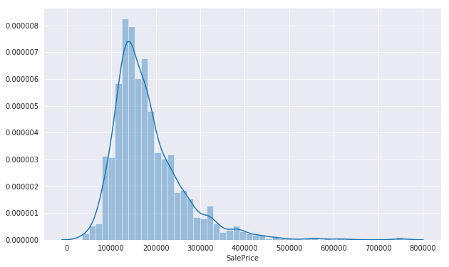

```python
f, ax = plt.subplots(figsize=(10, 6))
sns.distplot(df.SalePrice)
plt.show()
```

```python
df['SalePrice_Category'] = np.ceil(df["SalePrice"] / 120000)
df.SalePrice_Category.value_counts().sort_index()
```

```
1.0    269
2.0    946
3.0    194
4.0     41
5.0      6
6.0      2
7.0      2
Name: SalePrice_Category, dtype: int64
```

Se crearon 7 categorías. Sin embargo, como se observa en la gráfica anterior, los últimos valores son atípicos. Por lo tanto, se decide que todas las categorías arriba de tres se unirán a esta.

```python
# Las que estén arriba de 3 se unen a la categoría 3
df["SalePrice_Category"].where(df["SalePrice_Category"] < 3, 3.0, inplace=True)
df.SalePrice_Category.value_counts().sort_index()
```

```
1.0    269
2.0    946
3.0    245
Name: SalePrice_Category, dtype: int64
```

Como resultado, se crearon las tres variables de Bajo, Medio y Alto.

## 2. Regresión Lineal

### Selección de variables

Utilizando el mismo análisis que se utilizó en el análisis exploratorio, se realizará un análisis de correlación para encontrar las variables más importantes para el análisis.

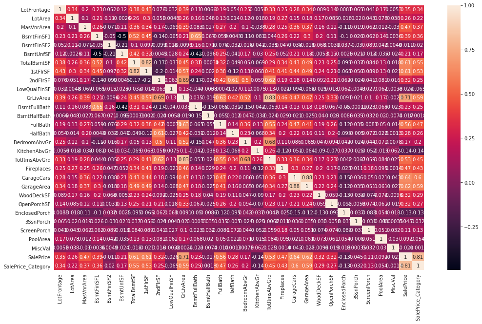

```python
corr = df.corr()
f, ax = plt.subplots(figsize=(17, 10))
sns.heatmap(corr, cbar=True, annot=True,
            xticklabels=corr.columns.values,
            yticklabels=corr.columns.values)
```

Estas son las variables que parecen tener mayor correlación con el precio.

### Creando el modelo

Se utilizan las variables con mayor correlación para crear el modelo.

```python
columnas_predictoras = ['GrLivArea', 'GarageArea', 'TotalBsmtSF', 'FullBath']
x = df[columnas_predictoras]
y = df.SalePrice
x_train, x_test, y_train, y_test = train_test_split(x, y, test_size=0.4, random_state=123)
```

Se crea el modelo.

```python
linreg = LinearRegression()
linreg.fit(x_train, y_train)
```

```
LinearRegression(copy_X=True, fit_intercept=True, n_jobs=None, normalize=False)
```

```python
print(linreg.intercept_)
print(linreg.coef_)
```

```
-31640.877420419536
[   56.11831596    91.99236417    46.61952422 21293.1919139 ]
```

### Predicción con el modelo

Se realizará una predicción utilizando el modelo creado.

```python
linreg.predict(x_test)
```

```
array([206282.62484663, 233209.82963236, 187253.34409149, 233911.59612382,
       146142.07725388, 226089.59131384, 285481.54125157, 109996.90643724,
       174756.82512899, 104718.69549654, 157089.87021917, 207290.74573347,
       144901.21205548, 114645.49623729, 226909.70608528, 177970.55814491,
       119947.28641756, 257258.05793267, 203706.78349072, 157082.77536065,
       140254.48556421, 191685.79659883, 105510.59069818, 132927.87548061,
       215431.28915273, 164174.59389671, 210365.92993466, 190330.87232387,
       135821.04365416, 162126.8325687 , 140744.31292704, 201811.47698938,
       180410.3255427 , 204976.44795777, 261288.08559219, 217487.91425801,
       167217.9358502 , 342301.78960487, 179488.54080657, 103201.91224312,
       124785.45769119, 222933.05483496, 181505.3001646 , 173677.55318689,
       224195.48702541, 113492.57740707, 260577.01680038, 203085.62206795,
       227239.7199178 , 117539.06502673, 189862.24626261, 202524.36092819,
       141687.56878192, 174660.13453766,  83426.29495784, 162329.54531085,
       115730.53692777, 178665.93106617, 232348.08768064, 273560.72439169,
       121970.7595463 , 303182.63596696, 167116.52141018, 169236.51996007,
       208336.11744232, 162238.11660458, 113957.76600139, 241709.42554367,
       235308.22503568, 151603.02719115, 137813.29137629, 246933.08166682,
       167725.83160275, 258111.56844377, 162237.88549903, 102800.13485258,
       168284.131775  , 161248.89779737, 206028.35345708, 100162.17649826,
       266606.73557805, 332777.71823496,  58931.7217193 , 131317.32786606,
       263645.65455108, 156784.53235739,  78417.80841012, 100914.79708247,
        60849.63773912, 257883.55013763, 159093.4357585 , 187365.37579627,
       173795.58896438, 159332.23495927, 136248.71290211, 142742.02616614,
       226014.50374955, 109833.59178089, 217187.45118384, 109511.22750064,
       130783.4920252 , 365275.05241473, 313423.2182088 , 168854.65086813,
       210108.08640039, 153311.57552388, 114148.5810685 , 179866.99833395,
       174940.61795844, 274461.83523442, 269507.81178966, 200782.86770278,
       126741.27100686, 266934.93851568, 193190.93225395,  85927.37815503,
       175911.03816458, 300741.52185222,  98016.11688762, 150415.53489416,
       163792.52662261, 211605.16486574, 195604.22467447, 131037.44071715,
       216052.48626837, 259712.39198264, 100018.89518011, 123702.16580773,
       156737.44224814, 286527.18369915, 175213.12321069, 236352.88224231,
       266488.37331671, 171121.98665062, 176158.59316441, 212024.86906862,
       261881.47965109,  98153.55708408, 181415.58527989, 128096.92311745,
        98886.24833641, 218817.86040708, 240291.60019697, 120577.99812505,
       227106.20055403, 234366.79846324, 246814.08112471, 193892.32169074,
       208066.54802264, 143335.47414653, 163427.12429584, 156518.23902672,
       351918.65348974, 171191.52868842, 247429.97854087, 158464.66651205,
       241029.09540211, 128335.83685332, 143776.93289964, 141729.51628832,
```

[output cut: 91 more lines]

```
       235338.69922805,  96816.28124475, 244932.84346195, 175160.25000535,
       271973.78425964, 199122.73710127, 225498.47026992, 175775.3972222 ,
       182990.64070573, 153435.26689846, 228441.98656535, 143390.35335431,
       193009.69617552, 122896.50749347, 116854.98229671, 132806.84418089,
       215137.04675015, 305025.67815483,  78417.80841012, 160675.45266031,
       228136.33139623, 133046.27442486, 133468.54156742, 133464.36964122,
       151706.2561612 , 199264.52193686, 249624.95615753, 163389.73374616,
       169118.6674904 , 122061.48840995, 212723.46627959, 201916.97031721,
       216142.9266548 , 110613.01250428, 189601.07982988, 250621.91454023,
       189130.07210203, 118416.92102012, 197851.89084   , 115150.12394104,
       265538.09380579, 182707.22311221, 244223.2484238 ,  90824.19825774,
       113625.92806011, 286150.85917883, 151233.81332884, 148503.40865599,
       294025.51727375, 181990.17174263, 183473.3252867 , 143186.89115542,
       175068.88898955, 122675.5694172 , 139627.86044324, 198267.03392924,
       220041.99549203, 298110.40615572,  83562.60725724, 188823.27609805])
```

### Análisis de la predicción del modelo utilizando RMSE

Se utilizará el RMSE para verificar la calidad del modelo contra los valores reales. Este criterio mide la diferencia entre los precios reales y los predichos.

```python
mse = mean_squared_error(y_test, linreg.predict(x_test))
```

```python
print(np.sqrt(mse))
```

```
43436.00382214862
```

```python
print(linreg.score(x_test,y_test))
```

```
0.693274241878693
```

### Variables más importantes

Las variables que resultaron ser más significativas para el modelo fueron: 'GrLivArea', 'GarageArea', 'TotalBsmtSF', 'FullBath'.

## K Nearest Neighbors

### Creación de variable categórica para la variable que se utilizará para estretificación

Se quiere utilizar una variable para realizar el sampleo estratificado. Para ello se utilizará el resultado de la correlación realizada en secciones anteriores.

```python
corr = df.corr()
corr['SalePrice'].sort_values(ascending=False)
```

```
SalePrice             1.000000
SalePrice_Category    0.808884
GrLivArea             0.708624
GarageCars            0.640409
GarageArea            0.623431
TotalBsmtSF           0.613581
1stFlrSF              0.605852
FullBath              0.560664
TotRmsAbvGrd          0.533723
MasVnrArea            0.472614
Fireplaces            0.466929
BsmtFinSF1            0.386420
LotFrontage           0.349876
WoodDeckSF            0.324413
2ndFlrSF              0.319334
OpenPorchSF           0.315856
HalfBath              0.284108
LotArea               0.263843
BsmtFullBath          0.227122
BsmtUnfSF             0.214479
BedroomAbvGr          0.168213
ScreenPorch           0.111447
PoolArea              0.092404
3SsnPorch             0.044584
BsmtFinSF2           -0.011378
BsmtHalfBath         -0.016844
MiscVal              -0.021190
LowQualFinSF         -0.025606
EnclosedPorch        -0.128578
KitchenAbvGr         -0.135907
Name: SalePrice, dtype: float64
```

Como se observa en el resultado anterior, la variable más correlacionada con el precio es GrLivArea. Por lo tanto nos interesa para realizar nuestra estratificación.

Se procede a análizar la variable GrLivArea para decidir cuántas categorías debería tener.

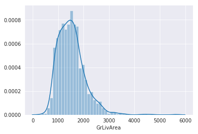

```python
sns.distplot(df.GrLivArea)
plt.show()
```

De la gráfica anterior, se observa que la mayoría de valores de GrLivArea se encuentran entre 1000 y 2000, y luego se tiene una cola hacia la derecha.

Ahora se procede a la creación de las categorías para dicha variable.

```python
df['GrLivArea_Category'] = np.ceil(df["GrLivArea"] / 500)
df.GrLivArea_Category.value_counts().sort_index()
```

```
1.0       3
2.0     228
3.0     554
4.0     461
5.0     144
6.0      52
7.0      12
8.0       2
9.0       2
10.0      1
12.0      1
Name: GrLivArea_Category, dtype: int64
```

Sin embargo, nos interesa tener menos categorías, ya que las últimas ya casi no tienen casas en ellas.

```python
# Las que estén arriba de 5 se unen a la categoría 5
df["GrLivArea_Category"].where(df["GrLivArea_Category"] < 5, 5.0, inplace=True)
df.GrLivArea_Category.value_counts().sort_index()
```

```
1.0      3
2.0    228
3.0    554
4.0    461
5.0    214
Name: GrLivArea_Category, dtype: int64
```

### Muestreo estratificado

Para este modelo se utilizará un tipo de muestreo diferente al utilizado para regresión lineal. Las ventajas del muestreo estratificado es que si un subgrupo de casas no se encuentra correctamente representado, podría alterar las predicciones.

```python
df = df.select_dtypes(exclude=['category'])
split = StratifiedShuffleSplit(n_splits=1, test_size=0.4, random_state=42)
for train_index, test_index in split.split(df, df["GrLivArea_Category"]):
    strat_train_set = df.loc[train_index]
    strat_test_set = df.loc[test_index]
strat_test_set.head()
```

|  | LotFrontage | LotArea | MasVnrArea | BsmtFinSF1 | BsmtFinSF2 | BsmtUnfSF | TotalBsmtSF | 1stFlrSF | 2ndFlrSF | LowQualFinSF | GrLivArea | BsmtFullBath | BsmtHalfBath | FullBath | HalfBath | BedroomAbvGr | KitchenAbvGr | TotRmsAbvGrd | Fireplaces | GarageCars | GarageArea | WoodDeckSF | OpenPorchSF | EnclosedPorch | 3SsnPorch | ScreenPorch | PoolArea | MiscVal | SalePrice | … |
| --- | --- | --- | --- | --- | --- | --- | --- | --- | --- | --- | --- | --- | --- | --- | --- | --- | --- | --- | --- | --- | --- | --- | --- | --- | --- | --- | --- | --- | --- | --- |
| 608 | 78.0 | 12168 | 0.0 | 428 | 0 | 537 | 965 | 1940 | 1254 | 0 | 3194 | 0 | 0 | 2 | 1 | 4 | 1 | 10 | 2 | 2 | 380 | 0 | 0 | 0 | 0 | 0 | 0 | 0 | 359100 | … |
| 294 | 80.0 | 9600 | 238.0 | 1285 | 0 | 131 | 1416 | 1644 | 0 | 0 | 1644 | 1 | 0 | 1 | 0 | 3 | 1 | 7 | 2 | 2 | 418 | 110 | 0 | 0 | 0 | 0 | 0 | 0 | 167000 | … |
| 392 | 73.0 | 8339 | 0.0 | 0 | 0 | 0 | 0 | 882 | 0 | 0 | 882 | 0 | 0 | 1 | 0 | 3 | 1 | 5 | 0 | 1 | 294 | 0 | 0 | 0 | 0 | 0 | 0 | 1200 | 106500 | … |
| 1254 | 60.0 | 6931 | 92.0 | 0 | 0 | 746 | 746 | 760 | 896 | 0 | 1656 | 0 | 0 | 2 | 1 | 3 | 1 | 7 | 1 | 2 | 397 | 178 | 128 | 0 | 0 | 0 | 0 | 0 | 165400 | … |
| 273 | 80.0 | 9600 | 183.0 | 620 | 620 | 0 | 1240 | 1632 | 0 | 0 | 1632 | 1 | 0 | 2 | 0 | 3 | 1 | 6 | 1 | 1 | 338 | 289 | 0 | 0 | 0 | 0 | 0 | 0 | 139000 | … |

### Creación del modelo

Ahora se diseñará el modelo, primero se elegirán las variables más significativas.

```python
# Entrenamiento
strat_train_set
# Prueba
strat_test_set
```

|  | LotFrontage | LotArea | MasVnrArea | BsmtFinSF1 | BsmtFinSF2 | BsmtUnfSF | TotalBsmtSF | 1stFlrSF | 2ndFlrSF | LowQualFinSF | GrLivArea | BsmtFullBath | BsmtHalfBath | FullBath | HalfBath | BedroomAbvGr | KitchenAbvGr | TotRmsAbvGrd | Fireplaces | GarageCars | GarageArea | WoodDeckSF | OpenPorchSF | EnclosedPorch | 3SsnPorch | ScreenPorch | PoolArea | MiscVal | SalePrice | … |
| --- | --- | --- | --- | --- | --- | --- | --- | --- | --- | --- | --- | --- | --- | --- | --- | --- | --- | --- | --- | --- | --- | --- | --- | --- | --- | --- | --- | --- | --- | --- |
| 608 | 78.0 | 12168 | 0.0 | 428 | 0 | 537 | 965 | 1940 | 1254 | 0 | 3194 | 0 | 0 | 2 | 1 | 4 | 1 | 10 | 2 | 2 | 380 | 0 | 0 | 0 | 0 | 0 | 0 | 0 | 359100 | … |
| 294 | 80.0 | 9600 | 238.0 | 1285 | 0 | 131 | 1416 | 1644 | 0 | 0 | 1644 | 1 | 0 | 1 | 0 | 3 | 1 | 7 | 2 | 2 | 418 | 110 | 0 | 0 | 0 | 0 | 0 | 0 | 167000 | … |
| 392 | 73.0 | 8339 | 0.0 | 0 | 0 | 0 | 0 | 882 | 0 | 0 | 882 | 0 | 0 | 1 | 0 | 3 | 1 | 5 | 0 | 1 | 294 | 0 | 0 | 0 | 0 | 0 | 0 | 1200 | 106500 | … |
| 1254 | 60.0 | 6931 | 92.0 | 0 | 0 | 746 | 746 | 760 | 896 | 0 | 1656 | 0 | 0 | 2 | 1 | 3 | 1 | 7 | 1 | 2 | 397 | 178 | 128 | 0 | 0 | 0 | 0 | 0 | 165400 | … |
| 273 | 80.0 | 9600 | 183.0 | 620 | 620 | 0 | 1240 | 1632 | 0 | 0 | 1632 | 1 | 0 | 2 | 0 | 3 | 1 | 6 | 1 | 1 | 338 | 289 | 0 | 0 | 0 | 0 | 0 | 0 | 139000 | … |
| 1187 | 89.0 | 12461 | 0.0 | 1456 | 0 | 168 | 1624 | 1624 | 0 | 0 | 1624 | 1 | 0 | 2 | 0 | 2 | 1 | 5 | 1 | 3 | 757 | 0 | 114 | 192 | 0 | 0 | 0 | 0 | 262000 | … |
| 279 | 83.0 | 10005 | 299.0 | 392 | 0 | 768 | 1160 | 1156 | 866 | 0 | 2022 | 0 | 0 | 2 | 1 | 4 | 1 | 8 | 1 | 2 | 505 | 288 | 117 | 0 | 0 | 0 | 0 | 0 | 192000 | … |
| 1285 | 50.0 | 6000 | 0.0 | 0 | 0 | 780 | 780 | 825 | 587 | 0 | 1412 | 0 | 0 | 1 | 0 | 4 | 1 | 6 | 1 | 1 | 280 | 45 | 0 | 0 | 0 | 0 | 0 | 0 | 132500 | … |
| 742 | 65.0 | 8450 | 108.0 | 0 | 0 | 1349 | 1349 | 1349 | 0 | 0 | 1349 | 0 | 0 | 2 | 0 | 3 | 1 | 6 | 0 | 2 | 539 | 120 | 55 | 0 | 0 | 0 | 0 | 0 | 179000 | … |
| 758 | 24.0 | 2280 | 360.0 | 549 | 0 | 195 | 744 | 757 | 744 | 0 | 1501 | 0 | 0 | 2 | 1 | 3 | 1 | 6 | 0 | 2 | 440 | 0 | 0 | 0 | 0 | 0 | 0 | 0 | 179400 | … |
| 87 | 40.0 | 3951 | 76.0 | 0 | 0 | 612 | 612 | 612 | 612 | 0 | 1224 | 0 | 0 | 2 | 1 | 2 | 1 | 4 | 0 | 2 | 528 | 0 | 234 | 0 | 0 | 0 | 0 | 0 | 164500 | … |
| 995 | 51.0 | 4712 | 0.0 | 384 | 0 | 363 | 747 | 774 | 456 | 0 | 1230 | 1 | 0 | 1 | 1 | 3 | 1 | 5 | 0 | 1 | 305 | 0 | 57 | 0 | 0 | 63 | 0 | 0 | 121600 | … |
| 1269 | 78.0 | 11344 | 180.0 | 460 | 0 | 414 | 874 | 874 | 650 | 0 | 1524 | 0 | 0 | 1 | 1 | 3 | 1 | 7 | 0 | 1 | 315 | 0 | 0 | 0 | 0 | 0 | 0 | 0 | 144000 | … |
| 469 | 76.0 | 9291 | 120.0 | 426 | 0 | 406 | 832 | 832 | 878 | 0 | 1710 | 0 | 0 | 2 | 1 | 3 | 1 | 7 | 0 | 2 | 506 | 144 | 70 | 0 | 0 | 0 | 0 | 0 | 187000 | … |
| 1223 | 89.0 | 10680 | 44.0 | 756 | 0 | 1380 | 2136 | 2136 | 0 | 0 | 2136 | 0 | 0 | 2 | 0 | 4 | 1 | 7 | 0 | 2 | 528 | 0 | 30 | 0 | 0 | 0 | 0 | 0 | 137900 | … |
| 581 | 98.0 | 12704 | 306.0 | 0 | 0 | 2042 | 2042 | 2042 | 0 | 0 | 2042 | 0 | 0 | 2 | 1 | 3 | 1 | 8 | 1 | 3 | 1390 | 0 | 90 | 0 | 0 | 0 | 0 | 0 | 253293 | … |
| 989 | 65.0 | 8125 | 0.0 | 0 | 0 | 770 | 770 | 778 | 798 | 0 | 1576 | 0 | 0 | 2 | 1 | 3 | 1 | 6 | 0 | 2 | 614 | 0 | 50 | 0 | 0 | 0 | 0 | 0 | 197000 | … |
| 266 | 70.0 | 11207 | 0.0 | 714 | 0 | 88 | 802 | 802 | 709 | 0 | 1511 | 1 | 0 | 2 | 1 | 3 | 1 | 8 | 1 | 2 | 413 | 95 | 75 | 0 | 0 | 0 | 0 | 0 | 185000 | … |
| 1377 | 60.0 | 10998 | 0.0 | 408 | 420 | 156 | 984 | 984 | 620 | 0 | 1604 | 0 | 0 | 2 | 0 | 3 | 1 | 6 | 0 | 2 | 660 | 0 | 68 | 0 | 0 | 0 | 0 | 0 | 117000 | … |
| 1044 | 80.0 | 9600 | 0.0 | 1104 | 0 | 1420 | 2524 | 2524 | 0 | 0 | 2524 | 1 | 0 | 2 | 1 | 4 | 1 | 9 | 1 | 2 | 542 | 474 | 120 | 0 | 0 | 0 | 0 | 0 | 278000 | … |
| 1060 | 41.0 | 4920 | 0.0 | 616 | 0 | 722 | 1338 | 1338 | 0 | 0 | 1338 | 1 | 0 | 2 | 0 | 2 | 1 | 6 | 0 | 2 | 582 | 0 | 0 | 170 | 0 | 0 | 0 | 0 | 213500 | … |
| 644 | 85.0 | 9187 | 162.0 | 1121 | 0 | 645 | 1766 | 1766 | 0 | 0 | 1766 | 1 | 0 | 2 | 1 | 2 | 1 | 7 | 1 | 3 | 478 | 195 | 130 | 0 | 0 | 0 | 0 | 0 | 370878 | … |
| 321 | 99.0 | 12099 | 388.0 | 970 | 0 | 166 | 1136 | 1136 | 1332 | 0 | 2468 | 1 | 0 | 2 | 1 | 4 | 1 | 10 | 1 | 3 | 872 | 184 | 154 | 0 | 0 | 0 | 0 | 0 | 354000 | … |
| 268 | 71.0 | 6900 | 0.0 | 403 | 125 | 212 | 740 | 778 | 0 | 0 | 778 | 0 | 0 | 1 | 0 | 2 | 1 | 4 | 1 | 1 | 924 | 0 | 25 | 0 | 0 | 0 | 0 | 0 | 120500 | … |
| 1129 | 60.0 | 7200 | 180.0 | 936 | 0 | 0 | 936 | 936 | 0 | 0 | 936 | 1 | 0 | 1 | 0 | 2 | 1 | 4 | 0 | 2 | 672 | 49 | 0 | 0 | 0 | 0 | 0 | 0 | 140000 | … |
| 341 | 60.0 | 8400 | 0.0 | 0 | 0 | 721 | 721 | 841 | 0 | 0 | 841 | 0 | 0 | 1 | 0 | 2 | 1 | 4 | 0 | 1 | 294 | 250 | 0 | 24 | 0 | 0 | 0 | 0 | 82000 | … |
| 878 | 88.0 | 11782 | 0.0 | 899 | 0 | 210 | 1109 | 1155 | 0 | 0 | 1155 | 1 | 0 | 1 | 0 | 3 | 1 | 6 | 0 | 2 | 576 | 192 | 0 | 0 | 0 | 0 | 0 | 400 | 148000 | … |
| 18 | 66.0 | 13695 | 0.0 | 646 | 0 | 468 | 1114 | 1114 | 0 | 0 | 1114 | 1 | 0 | 1 | 1 | 3 | 1 | 6 | 0 | 2 | 576 | 0 | 102 | 0 | 0 | 0 | 0 | 0 | 159000 | … |
| 555 | 58.0 | 6380 | 0.0 | 0 | 0 | 993 | 993 | 1048 | 0 | 0 | 1048 | 0 | 0 | 1 | 0 | 2 | 1 | 5 | 1 | 1 | 280 | 0 | 0 | 116 | 0 | 0 | 0 | 0 | 113000 | … |
| 1112 | 73.0 | 7100 | 0.0 | 708 | 0 | 108 | 816 | 816 | 0 | 0 | 816 | 1 | 0 | 1 | 0 | 2 | 1 | 5 | 0 | 1 | 308 | 0 | 0 | 0 | 0 | 0 | 0 | 0 | 129900 | … |
| ... | ... | ... | ... | ... | ... | ... | ... | ... | ... | ... | ... | ... | ... | ... | ... | ... | ... | ... | ... | ... | ... | ... | ... | ... | ... | ... | ... | ... | ... | … |
| 1390 | 70.0 | 9100 | 244.0 | 1400 | 0 | 125 | 1525 | 1525 | 0 | 0 | 1525 | 1 | 0 | 2 | 0 | 3 | 1 | 6 | 0 | 2 | 541 | 219 | 36 | 0 | 0 | 0 | 0 | 0 | 235000 | … |
| 107 | 50.0 | 6000 | 0.0 | 104 | 169 | 516 | 789 | 789 | 0 | 0 | 789 | 0 | 0 | 1 | 0 | 2 | 1 | 5 | 0 | 1 | 250 | 0 | 0 | 0 | 0 | 0 | 0 | 0 | 115000 | … |
| 752 | 79.0 | 9236 | 0.0 | 1200 | 0 | 279 | 1479 | 1494 | 0 | 0 | 1494 | 1 | 0 | 2 | 0 | 3 | 1 | 6 | 0 | 2 | 576 | 168 | 27 | 0 | 0 | 0 | 0 | 0 | 217000 | … |
| 264 | 30.0 | 5232 | 0.0 | 0 | 0 | 680 | 680 | 764 | 0 | 0 | 764 | 0 | 0 | 1 | 0 | 2 | 1 | 4 | 0 | 2 | 504 | 0 | 0 | 0 | 0 | 0 | 0 | 0 | 73000 | … |
| 105 | 75.0 | 9375 | 768.0 | 0 | 0 | 1053 | 1053 | 1053 | 939 | 0 | 1992 | 0 | 0 | 2 | 1 | 3 | 1 | 9 | 1 | 2 | 648 | 140 | 45 | 0 | 0 | 0 | 0 | 0 | 250000 | … |
| 704 | 70.0 | 8400 | 109.0 | 712 | 0 | 761 | 1473 | 1484 | 0 | 0 | 1484 | 1 | 0 | 2 | 0 | 3 | 1 | 7 | 0 | 2 | 606 | 0 | 35 | 0 | 144 | 0 | 0 | 0 | 213000 | … |
| 352 | 60.0 | 9084 | 0.0 | 236 | 380 | 0 | 616 | 616 | 495 | 0 | 1111 | 0 | 1 | 1 | 0 | 3 | 1 | 5 | 0 | 1 | 200 | 48 | 0 | 0 | 0 | 0 | 0 | 0 | 95000 | … |
| 943 | 100.0 | 25000 | 0.0 | 0 | 0 | 1632 | 1632 | 1632 | 0 | 0 | 1632 | 0 | 0 | 2 | 0 | 4 | 2 | 8 | 0 | 2 | 576 | 0 | 0 | 0 | 0 | 0 | 0 | 0 | 143000 | … |
| 237 | 66.5 | 9453 | 0.0 | 402 | 0 | 594 | 996 | 1014 | 730 | 0 | 1744 | 0 | 0 | 2 | 1 | 3 | 1 | 7 | 0 | 2 | 457 | 370 | 70 | 0 | 238 | 0 | 0 | 0 | 194500 | … |
| 816 | 73.0 | 11425 | 0.0 | 486 | 0 | 522 | 1008 | 1008 | 0 | 0 | 1008 | 0 | 0 | 1 | 0 | 2 | 1 | 4 | 1 | 1 | 275 | 0 | 0 | 120 | 0 | 0 | 0 | 0 | 137000 | … |
| 1068 | 42.0 | 3964 | 0.0 | 837 | 0 | 105 | 942 | 1291 | 1230 | 0 | 2521 | 1 | 0 | 2 | 1 | 5 | 1 | 10 | 1 | 2 | 576 | 728 | 20 | 0 | 0 | 0 | 0 | 0 | 151400 | … |
| 767 | 75.0 | 12508 | 0.0 | 660 | 0 | 323 | 983 | 983 | 767 | 0 | 1750 | 1 | 0 | 2 | 0 | 4 | 1 | 7 | 0 | 1 | 423 | 245 | 0 | 156 | 0 | 0 | 0 | 1300 | 160000 | … |
| 510 | 75.0 | 14559 | 70.0 | 650 | 180 | 178 | 1008 | 1363 | 0 | 0 | 1363 | 1 | 0 | 1 | 0 | 2 | 1 | 6 | 2 | 1 | 288 | 324 | 42 | 0 | 0 | 168 | 0 | 2000 | 164900 | … |
| 395 | 68.0 | 9571 | 0.0 | 739 | 0 | 405 | 1144 | 1144 | 0 | 0 | 1144 | 1 | 0 | 1 | 0 | 3 | 1 | 6 | 0 | 1 | 596 | 44 | 0 | 0 | 0 | 0 | 0 | 0 | 129000 | … |
| 343 | 63.0 | 8849 | 616.0 | 28 | 0 | 1656 | 1684 | 1684 | 0 | 0 | 1684 | 0 | 0 | 2 | 0 | 2 | 1 | 6 | 1 | 2 | 564 | 495 | 72 | 0 | 0 | 0 | 0 | 0 | 266000 | … |
| 136 | 73.0 | 10355 | 196.0 | 695 | 0 | 519 | 1214 | 1214 | 0 | 0 | 1214 | 0 | 0 | 2 | 0 | 3 | 1 | 5 | 1 | 1 | 318 | 0 | 111 | 0 | 0 | 0 | 0 | 0 | 143000 | … |
| 348 | 36.0 | 2448 | 106.0 | 573 | 0 | 191 | 764 | 764 | 862 | 0 | 1626 | 1 | 0 | 2 | 1 | 2 | 1 | 6 | 0 | 2 | 474 | 0 | 27 | 0 | 0 | 0 | 0 | 0 | 154000 | … |
| 784 | 35.0 | 6300 | 0.0 | 0 | 0 | 742 | 742 | 742 | 742 | 0 | 1484 | 0 | 0 | 2 | 0 | 3 | 1 | 9 | 1 | 0 | 0 | 0 | 291 | 134 | 0 | 0 | 0 | 0 | 128000 | … |
| 470 | 61.5 | 6820 | 0.0 | 368 | 1120 | 0 | 1488 | 1502 | 0 | 0 | 1502 | 1 | 0 | 1 | 1 | 1 | 1 | 4 | 0 | 2 | 528 | 0 | 54 | 0 | 0 | 140 | 0 | 0 | 212000 | … |
| 345 | 65.0 | 6435 | 0.0 | 0 | 0 | 972 | 972 | 972 | 605 | 0 | 1577 | 0 | 0 | 1 | 0 | 3 | 1 | 6 | 1 | 1 | 312 | 0 | 0 | 0 | 0 | 0 | 0 | 0 | 140200 | … |
| 1141 | 80.0 | 10304 | 44.0 | 381 | 0 | 399 | 780 | 1088 | 780 | 0 | 1868 | 1 | 0 | 2 | 1 | 4 | 1 | 9 | 1 | 2 | 484 | 448 | 96 | 0 | 0 | 0 | 0 | 0 | 197500 | … |
| 1204 | 78.0 | 10140 | 0.0 | 788 | 0 | 268 | 1056 | 1074 | 0 | 0 | 1074 | 1 | 0 | 1 | 1 | 3 | 1 | 6 | 0 | 2 | 495 | 0 | 88 | 0 | 0 | 0 | 0 | 0 | 153500 | … |
| 579 | 81.0 | 12150 | 335.0 | 0 | 0 | 1050 | 1050 | 1050 | 745 | 0 | 1795 | 0 | 0 | 2 | 0 | 4 | 1 | 7 | 0 | 1 | 352 | 0 | 0 | 0 | 0 | 0 | 0 | 0 | 131500 | … |
| 147 | 65.0 | 9505 | 180.0 | 0 | 0 | 884 | 884 | 884 | 1151 | 0 | 2035 | 0 | 0 | 2 | 1 | 3 | 1 | 8 | 1 | 2 | 434 | 144 | 48 | 0 | 0 | 0 | 0 | 0 | 222500 | … |
| 1205 | 90.0 | 14684 | 234.0 | 485 | 177 | 1496 | 2158 | 2196 | 0 | 0 | 2196 | 0 | 0 | 2 | 0 | 3 | 1 | 7 | 1 | 3 | 701 | 84 | 70 | 0 | 0 | 0 | 0 | 0 | 271900 | … |
| 58 | 66.0 | 13682 | 1031.0 | 0 | 0 | 1410 | 1410 | 1426 | 1519 | 0 | 2945 | 0 | 0 | 3 | 1 | 3 | 1 | 10 | 1 | 3 | 641 | 192 | 0 | 37 | 0 | 0 | 0 | 0 | 438780 | … |
| 1209 | 85.0 | 10182 | 420.0 | 1220 | 0 | 440 | 1660 | 1660 | 0 | 0 | 1660 | 1 | 0 | 2 | 0 | 3 | 1 | 8 | 1 | 2 | 500 | 322 | 50 | 0 | 0 | 0 | 0 | 0 | 290000 | … |
| 1242 | 85.0 | 10625 | 81.0 | 885 | 168 | 0 | 1053 | 1173 | 0 | 0 | 1173 | 1 | 0 | 2 | 0 | 3 | 1 | 6 | 2 | 2 | 528 | 0 | 120 | 0 | 0 | 0 | 0 | 0 | 170000 | … |
| 1166 | 64.0 | 10475 | 72.0 | 0 | 0 | 1694 | 1694 | 1694 | 0 | 0 | 1694 | 0 | 0 | 2 | 0 | 3 | 1 | 7 | 0 | 3 | 776 | 160 | 33 | 0 | 0 | 0 | 0 | 0 | 245350 | … |
| 1154 | 73.0 | 13700 | 288.0 | 454 | 0 | 410 | 864 | 902 | 918 | 0 | 1820 | 0 | 0 | 1 | 2 | 4 | 1 | 8 | 2 | 2 | 492 | 60 | 84 | 0 | 0 | 273 | 0 | 0 | 201800 | … |

584 rows × 31 columns

### KNN

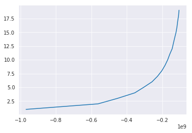

```python
df_numerical = df.select_dtypes(exclude=['category'])
X=np.array(df_numerical[["GarageArea","GarageCars","TotRmsAbvGrd","TotalBsmtSF","1stFlrSF","GrLivArea","FullBath"]])
Y = np.array(df_numerical[["SalePrice"]])
kmeans = [KMeans(n_clusters=i) for i in range(1,20)]
valor = [kmeans[i].fit(X).score(X) for i in range(len(kmeans))]
plt.plot(valor,range(1,20))
```

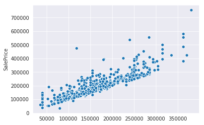

```python
input_feature = strat_train_set.columns.values.tolist()
train_X = strat_train_set.as_matrix(columns = input_feature)
scaler = preprocessing.StandardScaler().fit(train_X)
train_X_scaled = scaler.transform(train_X)
test_X = strat_test_set.as_matrix(columns = [input_feature])
test_X_scaled = scaler.transform(test_X)
knn = KNeighborsClassifier(n_neighbors=5)
knn.fit(train_X_scaled, strat_train_set.as_matrix(columns = ['SalePrice']))
pred = knn.predict(train_X_scaled)
sns.scatterplot(pred,strat_train_set["SalePrice"])
```

Utilizando el metodo del codo, se observo que la curva se realizaba cuando el valor de X era 5. Por ende se utilizo un valor de 5 para K. Por otro lado se puede observar una distribucion bastante linel entre los valores predecidos por el algorimo y los valores del precio de venta. Esto significa que se mantiene una tendencia en la muestra y existe un aumento de valor.

### Matriz de Confusión

```python
confusion_matrix(pred, pred)
```

```
array([[1, 0, 0, ..., 0, 0, 0],
       [0, 2, 0, ..., 0, 0, 0],
       [0, 0, 8, ..., 0, 0, 0],
       ...,
       [0, 0, 0, ..., 4, 0, 0],
       [0, 0, 0, ..., 0, 1, 0],
       [0, 0, 0, ..., 0, 0, 1]])
```

#### Probando el Algoritmo con los datos de Kaggle

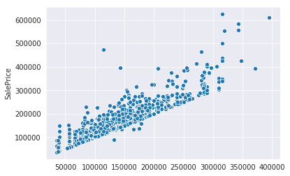

```python
trainDfNumerical = train_df.select_dtypes(exclude=['category'])

input_feature = trainDfNumerical.columns.values.tolist()
trainX = trainDfNumerical.as_matrix(columns = input_feature)
scaler = preprocessing.StandardScaler().fit(trainX)
trainX = scaler.transform(trainX)
testX = strat_test_set.as_matrix(columns = [input_feature])
testXScaled = scaler.transform(testX)
knn = neighbors.KNeighborsClassifier(n_neighbors=5)
knn.fit(trainX, train_df.as_matrix(columns = ['SalePrice']))
predK = knn.predict(trainX)
sns.scatterplot(predK,trainDfNumerical["SalePrice"])
```

#### Matriz de Confusión con datos de Kaggle

```python
confusion_matrix(predK,predK)
```

```
array([[3, 0, 0, ..., 0, 0, 0],
       [0, 4, 0, ..., 0, 0, 0],
       [0, 0, 3, ..., 0, 0, 0],
       ...,
       [0, 0, 0, ..., 1, 0, 0],
       [0, 0, 0, ..., 0, 1, 0],
       [0, 0, 0, ..., 0, 0, 1]])
```

## Validación cruzada

```python
regresion = RidgeCV(alphas=[1, 1e3, 1e6], store_cv_values=True)
regresion.fit(strat_train_set, strat_train_set)
crossMatrix = np.mean(regressor.cv_values_, axis=0)
print("Valor alpha de regression",regresion.alpha_)
print("cross validation matrix \n",crossMatrix)
prediccion = egresion.predict(strat_test_set)
print("valores predecidos\n",predict_y)
```

[output not shown]

El metodo RidgeCV automaticamente utiliza kfold para poder calcular los valores de la predicción. Por diseño, el algoritmo calcula el valor de alpha más apropiado para el modelo.

## Comparación de modelos

En base a los resultados, se considera que el algoritmo de validación cruzada es más sencillo de aplicar que el knn, ya que este no depende de obtener un valor para poder realizar la predicción buscada. Por otro lado, knn permite ventajas como es la modelación al gusto de la persona que esta aplicando el modelo ya que podemos utilizar cual sea el número para agrupar la data en N vecinos, pero no todos los valores daran un resultado valido.